# WARBL2 Configuration Tool

Compiled by Stuart Hertzog

May 2024

# Introduction

# Table of Contents

[figure not shown]

1. Introduction
2. Top Panel
3. Instrument Settings
4. Finger Vibrato and Slide
5. Note Trigger and Register Control
6. Pressure and IMU Mapping
7. Drones Control
8. Button Behavior
9. Optical Sensor Calibration
10. WARBL2 Settings

# Top Panel

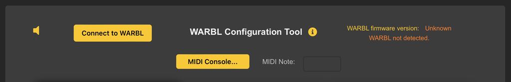

## Connect To WARBL The *Configuration Tool* will try to connect to WARBL if it is already plugged in or connected by *BLE MIDI* when the page is loaded, or you can click **Connect to WARBL** if it hasn’t connected automatically.

```
NOTE: If the WARBL2 Firmware is not up to date, you will be able to use the Configuration Tool, but some Options may be Dissing or disabled (shown in Grey).
```

## Volume Icon

The *Configuration Tool* can produce basic *Sounds* if you click the *Volume Icon*. This is meant for *Testing Purposes Only* and the *Sound* will not respond to *Pitch-Bend Commands* or *Control Change (CC) Messages*. On *iOS Devices* it’s also usually possible to have other *MIDI Apps* running at the same time as the *Configuration Tool*, which is preferable and will give you *Higher-Quality Sound*.

## MIDI Console Button

Tapping this will show the 300 *Most Recent MIDI Messages* received, useful for *Trouble Shooting*.

## MIDI Note Display

Will show the *MIDI Note* currently being played, as *Note Name Note Number*, also useful for *Trouble Shooting*.

## WARBL Firmware Version

This will show the *Firmware Version* of a connected WARBL2.

# Instrument Settings

## Per-Instrument Settings

## Default Instrument

## Fingering Pattern

## Transpose Menu

## Configure Custom Fingering

## Note Channel

## Bend Range

## Transient Note Filter (mS)

# Finger Vibrato and Slide

## Slide

## Vibrato

### Custom Vibrato

#### **Tin Whistle** and **Uilleann Pipes**

#### **GHB** and **Northumbrian Pipes**

## Legato Slide/Vibrato

## Advanced Pitch Bend Settings

### Finger-Sensing Distance

### Vibrato depth (cents)

### Legato Slide Limit (semitones)

## Send Pitch Bend Immediately Before Note On

## Send Notes As Legato

## Single Register

## Overblow

## Thumb Register

## Bell Register

## Calibrate at startup

## Learn or Enter Pressure

## Invert Thumb/Bell Switch

## Bagless Mode

## Bag/Breath

## Advanced Register Control Settings

### Threshold

### Multiplier

### Hysteresis

### Jump and Drop Times

### Bag and Breath Defaults Buttons

## Pressure Graph

# Note Trigger and Register Control

## Single Register

## Overblow

## Thumb Register

## Bell Register

## Calibrate at startup

## Learn or Enter Pressure

## Invert Thumb/Bell Switch

## Bagless Mode

## Bag/Breath

## Advanced Register Control Settings

### Threshold

### Multiplier

### Hysteresis

### Jump and Drop Times

### Bag and Breath Defaults Buttons

## Pressure Graph

# Pressure and IMU Mapping

## Pressure Mapping

### Force Max Velocity

### Pitch Expression

### Pitch Expression Depth

### Override…

### Send Pressure Mapping

## IMU Mapping

### Pitchbend Vibrato

### Roll, Elevation, and Yaw Mapping

### Recentering Yaw

# Drones Control

## No Drone Control

## Use Secret Button

## Turn On/Off With Chanter

## Use Pressure

### Learn

# Button Behavior

## Momentary

## None

## Send MIDI Message

### Note On/Note Off

### CC Messages

### Send PC

### Increase PC and Decrease PC

### Additional Momentary Switches

### Auto Callibration

### Power Down

### Recenter the Yaw

### Show Battery Level

### “Secret” Button Commands

# Optical Sensor Calibration

## Auto-Calibrate All Sensors

## Auto-Calibrate Bell Sensor Only

## Save Fine Calibration

# WARBL2 Settings

## Battery Voltage

## BLE status

## Send BLE/USB

## Charge From USB Hosts

## Auto Power Off Time

## Calibrate Gyro

## Recenter The Yaw